# Tipología y Ciclo de Vida de los Datos: Práctica 2 - Limpieza y análisis de datos

Autor: Eréndira Teresa Navarro García

Enero 20202

# 1 Descripción del dataset. ¿Por qué es importante y qué pregunta/problema pretende responder?

El conjunto de datos utilizado es Dataset Adult https://archive.ics.uci.edu/ml/datasets/Adult, estos datos provienen del censo de 1994 en Estados Unidos. La extracción fue hecha por Barry Becker, el conjunto de datos ya tiene estos filtros ((AAGE>16) && (AGI>100) && (AFNLWGT>1)&& (HRSWK>0)). Lo que se busca con estos datos es identificar las cractaerísticas que determinan que una persona gane más o menos de 50 mil dólares al año.

# 2 Integración y selección de los datos de interés a analizar.

El conjunto de datos contiene los siguientes campos:

- label: >50K, <=50K (etiqueta).
- age: continuous (edad).
- workclass: Private, Self-emp-not-inc, Self-emp-inc, Federal-gov, Local-gov, State-gov, Without-pay, Never-worked (descripción del trabajo).
- fnlwgt: continuous (ponderador).
- education: Bachelors, Some-college, 11th, HS-grad, Prof-school, Assoc-acdm, Assoc-voc, 9th, 7th-8th, 12th, Masters, 1st-4th, 10th, Doctorate, 5th-6th, Preschool (último nivel de estudios).
- education-num: continuous (número de años de estudio).
- marital-status: Married-civ-spouse, Divorced, Never-married, Separated, Widowed, Married-spouse-absent, Married-AF-spouse (estatus marital).
- occupation: Tech-support, Craft-repair, Other-service, Sales, Exec-managerial, Prof-specialty, Handlers-cleaners, Machine-op-inspct, Adm-clerical, Farming-fishing, Transport-moving, Priv-house-serv, Protective-serv, Armed-Forces (tipo de ocupación).
- relationship: Wife, Own-child, Husband, Not-in-family, Other-relative, Unmarried (tipo de relación con las demás personas).
- race: White, Asian-Pac-Islander, Amer-Indian-Eskimo, Other, Black (raza).
- sex: Female, Male (sexo).
- capital-gain: continuous (ganancia de capital).
- capital-loss: continuous (pérdida de capital).
- hours-per-week: continuous (horas de trabajo por semana).
- native-country: United-States, Cambodia, England, Puerto-Rico, Canada, Germany, Outlying-US(Guam-USVI-etc), India, Japan, Greece, South, China, Cuba, Iran, Honduras, Philippines, Italy, Poland, Jamaica, Vietnam, Mexico, Portugal, Ireland, France, Dominican-Republic, Laos, Ecuador, Taiwan, Haiti, Columbia, Hungary, Guatemala, Nicaragua, Scotland, Thailand, Yugoslavia, El-Salvador, Trinadad&Tobago, Peru, Hong, Holand-Netherlands (pais de origen).

Partiendo de la descripción de los datos las variables relationship y marital-status son similares, al igual que education y education-num. Se buscaría categorizar la variables continuas y se excluirá el ponderador.

Lo que se bucaría es obtener modelos supervisados con el target de >50K / <=50K.

# 3 Limpieza de los datos.

> Lectura de dataset

Los datos vienen divididos ya en train y test set, para el tratamiento de los mismos se unirán ambos conjuntos. Se dividirán en variables categóricas y numéricas para su análisis posterior.

```r
# Librerías
library(dplyr)
library(ggplot2)
library(gridExtra)
library(leaps)
library(Hmisc)
library(stringr)
library(C50)
library(caret)
library(grid)

# Lectura de datos
adult_train <- read.csv('http://archive.ics.uci.edu/ml/machine-learning-databases/adult/adult.data',stringsAsFactors = FALSE, header = FALSE)

adult_test <- read.csv('https://archive.ics.uci.edu/ml/machine-learning-databases/adult/adult.test',stringsAsFactors = FALSE, header = FALSE,skip=1)

# Nombre de los atributos
names(adult_train) <- c("age","workclass","fnlwgt","education","education_num","marital_status","occupation","relationship","race","sex","capital_gain","capital_loss","hour_per_week","native_country","target")

names(adult_test) <- c("age","workclass","fnlwgt","education","education_num","marital_status","occupation","relationship","race","sex","capital_gain","capital_loss","hour_per_week","native_country","target")

adult_train["df"] <- "train"
adult_test["df"] <- "test"
```

```r
adult <- rbind(adult_train,adult_test)

# Verificamos estructura de los conjuntos de datos
str(adult)
```

```
## 'data.frame':    48842 obs. of  16 variables:
##  $ age           : int  39 50 38 53 28 37 49 52 31 42 ...
##  $ workclass     : chr  " State-gov" " Self-emp-not-inc" " Private" " Private" ...
##  $ fnlwgt        : int  77516 83311 215646 234721 338409 284582 160187 209642 45781 159449 ...
##  $ education     : chr  " Bachelors" " Bachelors" " HS-grad" " 11th" ...
##  $ education_num : int  13 13 9 7 13 14 5 9 14 13 ...
##  $ marital_status: chr  " Never-married" " Married-civ-spouse" " Divorced" " Married-civ-spouse" ...
##  $ occupation    : chr  " Adm-clerical" " Exec-managerial" " Handlers-cleaners" " Handlers-cleaners" ...
##  $ relationship  : chr  " Not-in-family" " Husband" " Not-in-family" " Husband" ...
##  $ race          : chr  " White" " White" " White" " Black" ...
##  $ sex           : chr  " Male" " Male" " Male" " Male" ...
##  $ capital_gain  : int  2174 0 0 0 0 0 0 0 14084 5178 ...
##  $ capital_loss  : int  0 0 0 0 0 0 0 0 0 0 ...
##  $ hour_per_week : int  40 13 40 40 40 40 16 45 50 40 ...
##  $ native_country: chr  " United-States" " United-States" " United-States" " United-States" ...
##  $ target        : chr  " <=50K" " <=50K" " <=50K" " <=50K" ...
##  $ df            : chr  "train" "train" "train" "train" ...
```

```r
catv <- c("workclass", "education", "marital_status", "occupation", "relationship",
          "race", "sex", "native_country", "target")

numv <- c("age", "capital_gain", "capital_loss", "hour_per_week")
```

## 3.1 ¿Los datos contienen ceros o elementos vacíos? ¿Cómo gestionarías cada uno de estos casos?

Los datos tienen elementos “desconocidos” y están marcados con el símbolo “?”, estos datos representan el 6% y están presentes en las variables workclass y occupation, al igual aparece esto en 2% de native-country.

Debido a la naturaleza de los datos, que provienen de un censo, se considera la posibilidad de utilizar la categoria “desconocido” como una categoría en si misma, sobre todo porque se planea agrupar categorias.

> Descriptivos variables categóricas:

```r
describe(adult[catv])
```

```
## adult[catv]
##
##  9  Variables      48842  Observations
## --------------------------------------------------------------------------------
## workclass
##        n  missing distinct
##    48842        0        9
##
## lowest :  ?                 Federal-gov       Local-gov         Never-worked      Private
## highest:  Private           Self-emp-inc      Self-emp-not-inc  State-gov         Without-pay
##
## ? (2799, 0.057), Federal-gov (1432, 0.029), Local-gov (3136, 0.064),
## Never-worked (10, 0.000), Private (33906, 0.694), Self-emp-inc (1695, 0.035),
## Self-emp-not-inc (3862, 0.079), State-gov (1981, 0.041), Without-pay (21,
## 0.000)
## --------------------------------------------------------------------------------
## education
##        n  missing distinct
##    48842        0       16
##
## lowest :  10th          11th          12th          1st-4th       5th-6th
## highest:  HS-grad       Masters       Preschool     Prof-school   Some-college
##
## 10th (1389, 0.028), 11th (1812, 0.037), 12th (657, 0.013), 1st-4th (247,
## 0.005), 5th-6th (509, 0.010), 7th-8th (955, 0.020), 9th (756, 0.015),
## Assoc-acdm (1601, 0.033), Assoc-voc (2061, 0.042), Bachelors (8025, 0.164),
## Doctorate (594, 0.012), HS-grad (15784, 0.323), Masters (2657, 0.054),
## Preschool (83, 0.002), Prof-school (834, 0.017), Some-college (10878, 0.223)
## --------------------------------------------------------------------------------
## marital_status
##        n  missing distinct
##    48842        0        7
##
## lowest :  Divorced               Married-AF-spouse      Married-civ-spouse     Married-spouse-absent  Never-married
## highest:  Married-civ-spouse     Married-spouse-absent  Never-married          Separated              Widowed
##
## Divorced (6633, 0.136), Married-AF-spouse (37, 0.001), Married-civ-spouse
## (22379, 0.458), Married-spouse-absent (628, 0.013), Never-married (16117,
## 0.330), Separated (1530, 0.031), Widowed (1518, 0.031)
## --------------------------------------------------------------------------------
```

[output cut: 52 more lines]

```
## native_country
##        n  missing distinct
##    48842        0       42
##
## lowest :  ?                Cambodia         Canada           China            Columbia
## highest:  Thailand         Trinadad&Tobago  United-States    Vietnam          Yugoslavia
## --------------------------------------------------------------------------------
## target
##        n  missing distinct
##    48842        0        4
##
## Value       <=50K <=50K.   >50K  >50K.
## Frequency   24720  12435   7841   3846
## Proportion  0.506  0.255  0.161  0.079
## --------------------------------------------------------------------------------
```

```r
dim(adult[adult["native_country"]==" ?",])[1]/dim(adult)[1]
```

```
## [1] 0.01754637
```

Para las variables numéricas no se observan datos nulos explícitos, pero debido a la distribución se identifica que los casos donde capital_gain=99999 son nulos.

> Descriptivos variables numéricas:

```r
########## Descriptivos numéricos
# librerìa para descriptivos numéricos
library(psych)

# Descriptivos numéricos
describe(adult[numv],quant=c(.25,.75))
```

```
##               vars     n    mean      sd median trimmed   mad min   max range
## age              1 48842   38.64   13.71     37   37.74 14.83  17    90    73
## capital_gain     2 48842 1079.07 7452.02      0    0.00  0.00   0 99999 99999
## capital_loss     3 48842   87.50  403.00      0    0.00  0.00   0  4356  4356
## hour_per_week    4 48842   40.42   12.39     40   40.54  4.45   1    99    98
##                skew kurtosis    se Q0.25 Q0.75
## age            0.56    -0.18  0.06    28    48
## capital_gain  11.89   152.67 33.72     0     0
## capital_loss   4.57    20.01  1.82     0     0
## hour_per_week  0.24     2.95  0.06    40    45
```

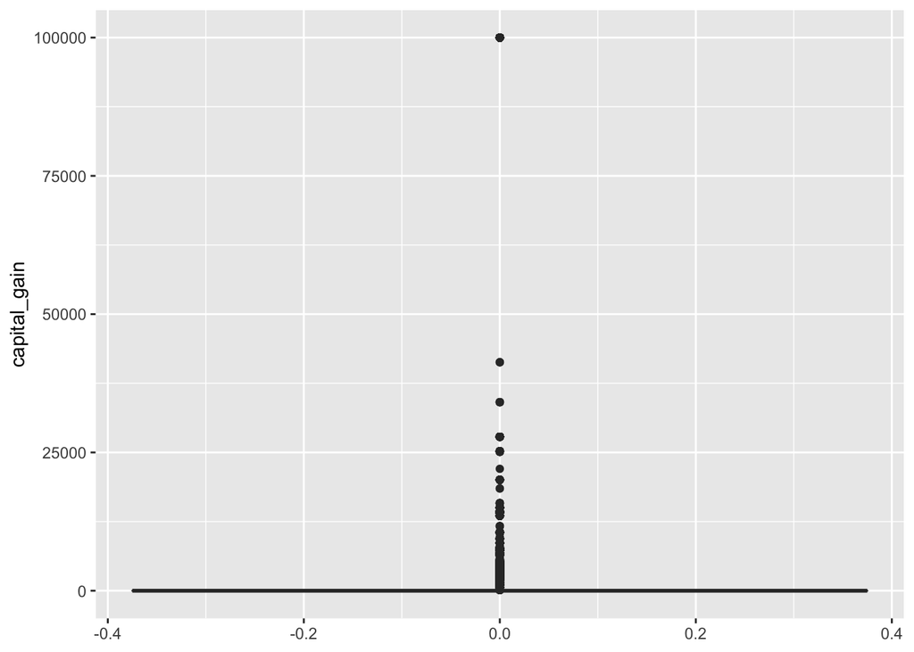

```r
# --------------- capital_gain ------------------
# boxplot para verificar el dato 99999
ggplot(data=adult, aes(y=capital_gain)) +
  geom_boxplot()
```

```r
# Se asume 99999 como valor nulo, debido a su distribución
nrow(adult[adult$capital_gain==99999,])
```

```
## [1] 244
```

```r
adult[adult$capital_gain == 99999,'capital_gain'] = NA
```

## 3.2 Identificación y tratamiento de valores extremos.

De acuerdo a la planeación, la variables numéricas se categorizarán, esto nos ayudará con los valores extremos presentes sobre todo en la variables de capital.

> Limpieza variables categóricas.
- Eliminar “.” de target

```r
# Limpiar texto y recategorizar

# --------------- target ------------------
# Se elimina el "." que está presente en registros del dataset en la variable target
adult$target <- gsub("[.]", "", trimws(tolower(adult$target)))
```

- Recategorización workclass

```r
# --------------- workclass ------------------
# muestra diferentes etiquetas -- INICIO
levels(as.factor(adult$workclass))
```

```
## [1] " ?"                " Federal-gov"      " Local-gov"
## [4] " Never-worked"     " Private"          " Self-emp-inc"
## [7] " Self-emp-not-inc" " State-gov"        " Without-pay"
```

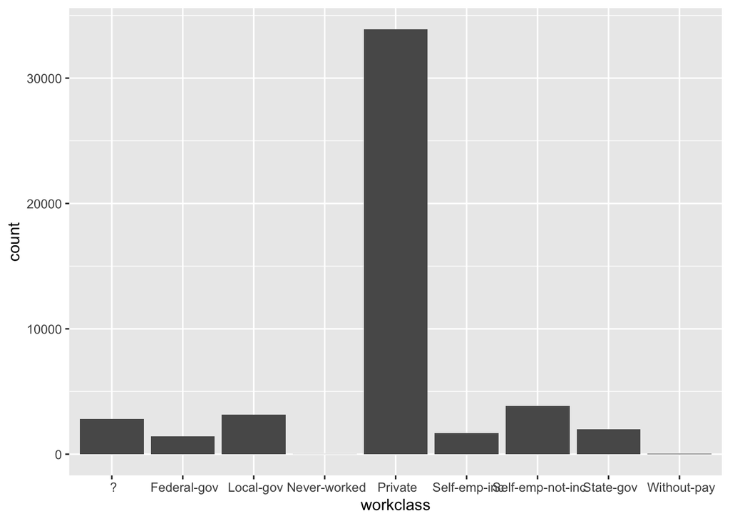

```r
# Distribución inicial
ggplot(data=adult,aes(x=workclass)) + geom_bar()
```

```r
# Estos valores se agrupan en 4 categorias generales: gov, priv, self y other
adult$workclass[grepl("gov",trimws(adult$workclass),ignore.case = T)] <- 'gov'
adult$workclass[grepl("self",trimws(adult$workclass),ignore.case = T)] <- 'self'
adult$workclass[grepl("(\\?|without|never)",
                      trimws(adult$workclass),ignore.case = T)] <- 'other'
adult$workclass[grepl("priv",trimws(adult$workclass),ignore.case = T)] <- 'priv'

#Verificar missing values
adult[is.na(adult$workclass)==TRUE,'workclass']
```

```
## character(0)
```

```r
# diferentes etiquetas -- FIN
levels(as.factor(adult$workclass))
```

```
## [1] "gov"   "other" "priv"  "self"
```

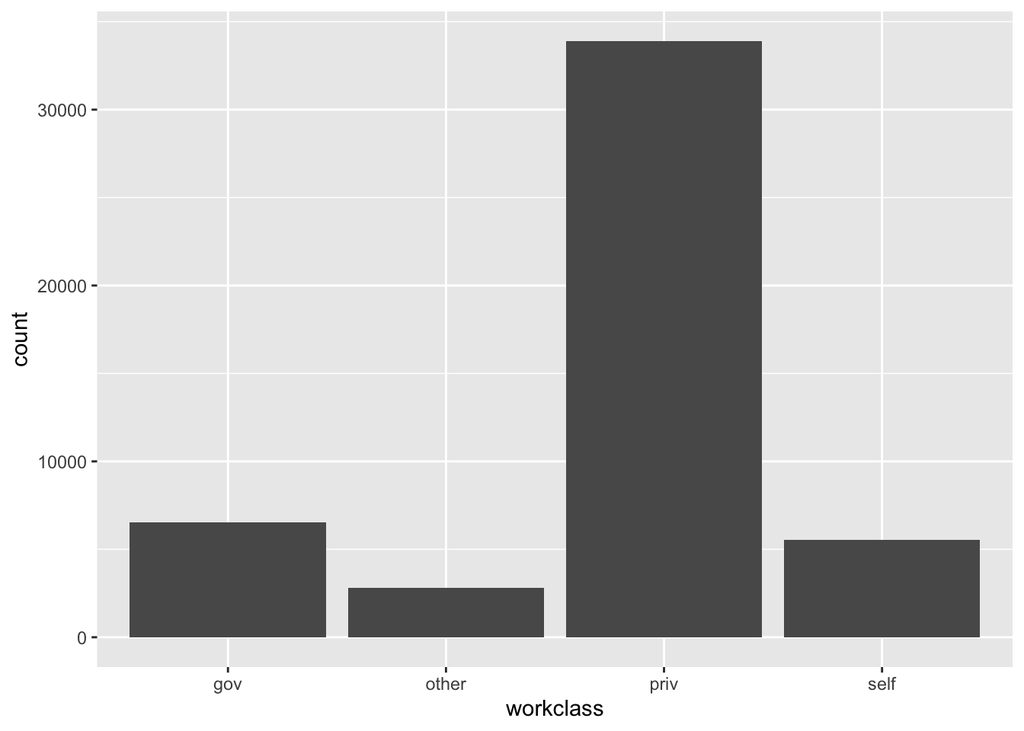

```r
# Distribución final
ggplot(data=adult,aes(x=workclass)) + geom_bar()
```

- Recategorización education

```r
# --------------- education ------------------
# diferentes etiquetas INCIO
levels(as.factor(adult$education))
```

```
##  [1] " 10th"         " 11th"         " 12th"         " 1st-4th"
##  [5] " 5th-6th"      " 7th-8th"      " 9th"          " Assoc-acdm"
##  [9] " Assoc-voc"    " Bachelors"    " Doctorate"    " HS-grad"
## [13] " Masters"      " Preschool"    " Prof-school"  " Some-college"
```

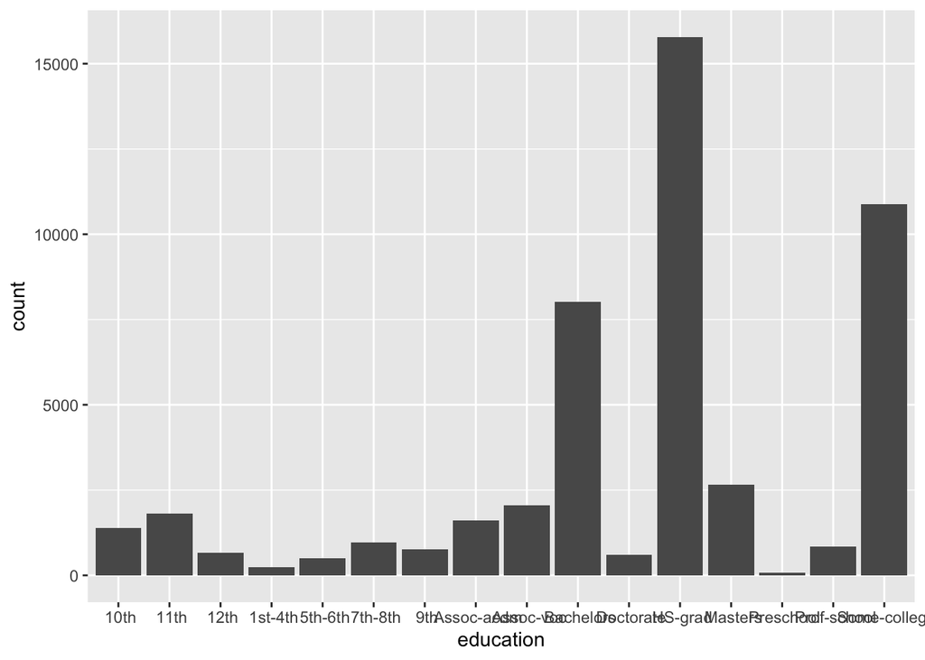

```r
# Distribución inicial
ggplot(data=adult,aes(x=education)) + geom_bar()
```

```r
# Estos valores se pueden agrupar en 5 categorias: no terminado, asociados, high school, bachelor y avanzado
adult$education[grepl("(th|preschool)",trimws(adult$education),ignore.case = T)] <- 'dropout'
adult$education[grepl("assoc",trimws(adult$education),ignore.case = T)] <- 'associates'
adult$education[grepl("(hs-|college)",trimws(adult$education),ignore.case = T)] <- 'hs_graduate'
adult$education[grepl("(prof|master|docto)",trimws(adult$education),ignore.case = T)] <- 'advanced'
# minúsculas, sin espacios
adult$education <- trimws(tolower(adult$education))

# diferentes etiquetas FINAL
levels(as.factor(adult$education))
```

```
## [1] "advanced"    "associates"  "bachelors"   "dropout"     "hs_graduate"
```

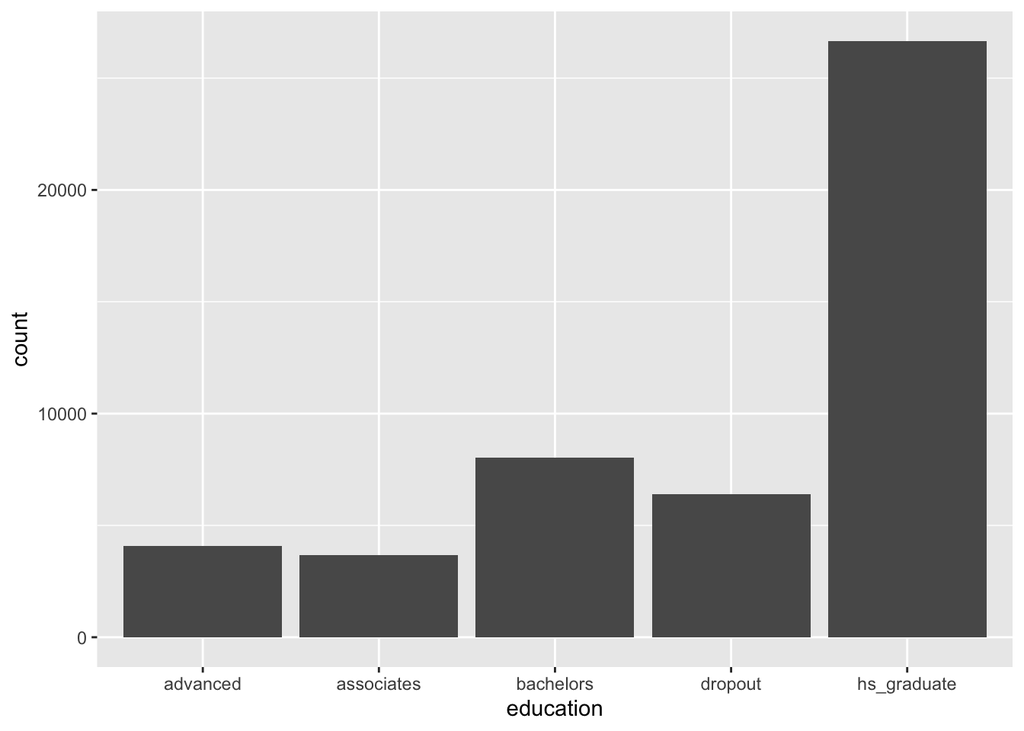

```r
# Distribución final
ggplot(data=adult,aes(x=education)) + geom_bar()
```

- Recategorización marital status

```r
# --------------- marital estatus ------------------
# diferentes etiquetas
levels(as.factor(adult$marital_status))
```

```
## [1] " Divorced"              " Married-AF-spouse"     " Married-civ-spouse"
## [4] " Married-spouse-absent" " Never-married"         " Separated"
## [7] " Widowed"
```

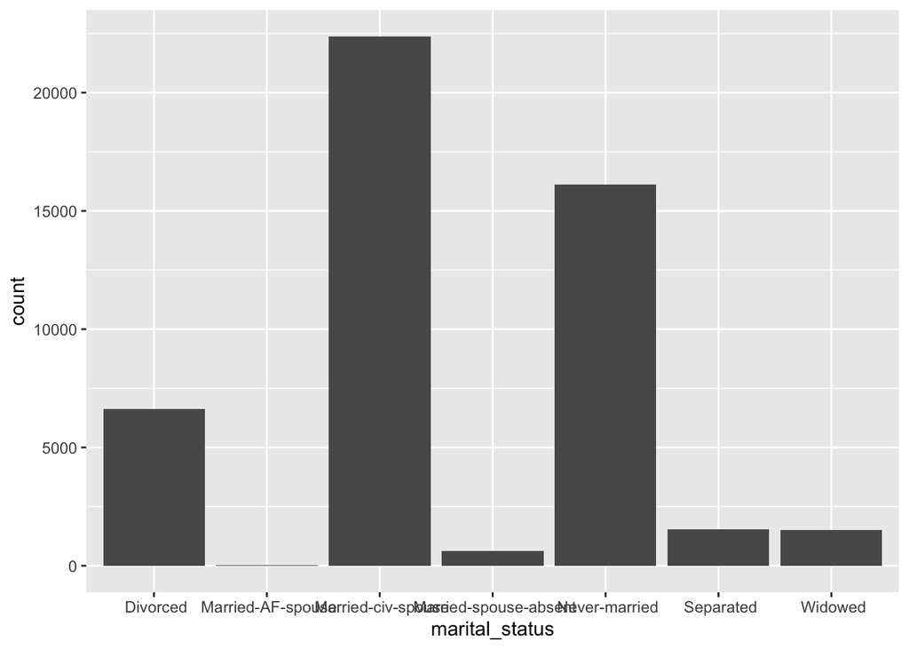

```r
# Distribución inicial
ggplot(data=adult,aes(x=marital_status)) + geom_bar()
```